# AFDMD-111 Estadística

Distribuciones de probabilidad

## Distribuciones discretas de probabilidad

Las distribuciones probabilidad se pueden clasificar en dos tipos importantes:

- Distribuciones discretas.
- Distribuciones continuas.

### Distribución de Bernoulli

Entre las distribuciones de probabilidad discretas podemos mencionar a la distribución de Bernoulli, la cual tiene la siguiente forma matemática:

$$p(k) = p^k(1-p)^{1-k}, \; \mbox{para} \; k\in (0,1)$$

En `R`, podemos simular muestras de la distribución de Bernoulli mediante el comando:

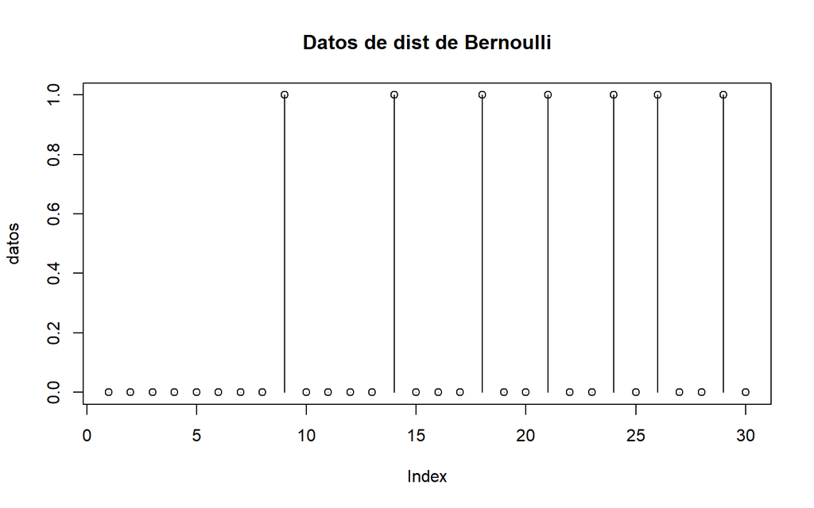

```r
# Sacamos una muestra de 30 datos Bernoulli y graficamos
datos <- rbinom(n=30, size=1, prob=0.3)
plot(datos, type="h", main="Datos de dist de Bernoulli")
points(datos)
```

En este caso size representa a $n$ que es igual a $1$. Otra distribución discreta importante es la Binomial (la de Bernoulli es un caso especial de ésta).

### Distribución Binomial

La distribución binomial representa el número de éxitos en $n$ intentos, mientras que la de Bernoulli, representa éxito o fracaso, la fórmula que representa a la distribución Binomial está dada por:

$$Pr(X=k) = {n\choose k} p^k(1-p)^{n-k}$$
En `R` podemos simular a la distribución Binomial como:

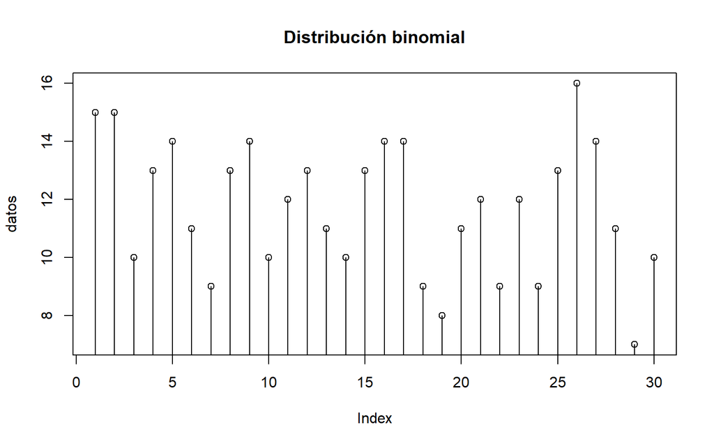

```r
datos <- rbinom(30, size=20, prob=0.6)
plot(datos, type="h", main= "Distribución binomial")
points(datos)
```

y si hacemos la probabilidad más pequeña ($p=0.1$), tenemos;

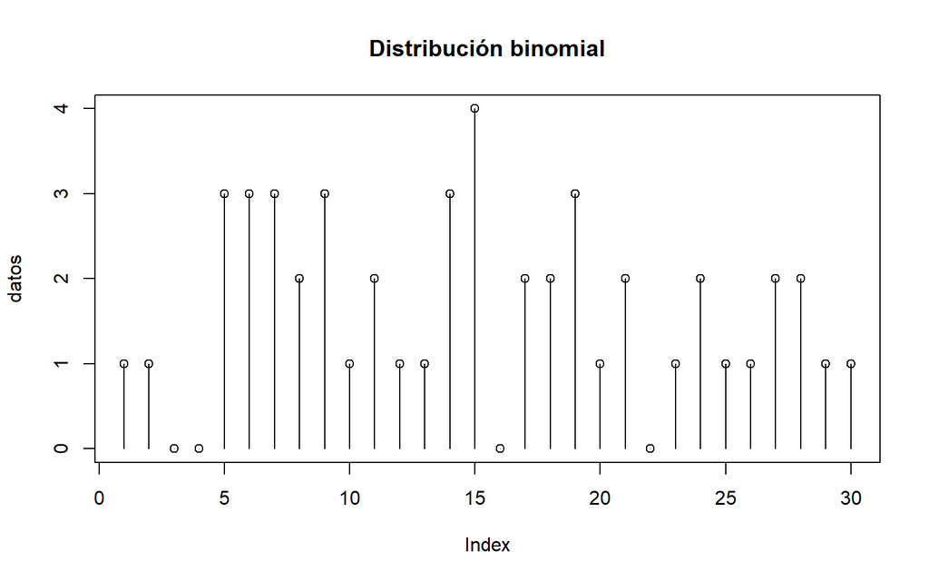

```r
datos <- rbinom(30, size=20, prob=0.1)
plot(datos, type="h", main= "Distribución binomial")
points(datos)
```

### Tarea

Investigar las siguiente distribuciones discretas y verificar cómo se pueden generar en `R` (Nota: no es necesario generarlos en `R`, es opcional).

- Distribución de Poison.
- Distribución Geométrica.
- Distribución Uniforme discreta.
- Distribución Hipergeométrica.

## Distribuciones continuas

En probabilidad los datos pueden ser continuos y discretos, cuando son discretos los modelamos mediante distribuciones discretas mientras si los datos tienen un continuo de valores, entonces se tienen que modelar mediante distribuciones de probabilidad continuas. Un ejemplo clásico de distribución continua es la distribución normal o Gaussiana. Las distribuciones continuas igual se representan mediante ecuaciones y en esto caso pueden ser representados por funciones llamadas PDFs o CDFs. A continuación definimos algunas de ellas.

### Distribución Gaussiana o normal

Se dice que los datos son Gaussianos cuando éstos vinieron de una distribución Gaussiana, la cual tiene la siguiente forma:

$$f(x) = \frac{1}{\sqrt{2\pi
\sigma^2}}\mbox{e}^{\frac{-(x-\mu)^2}{2\sigma^2}}$$

En `R` esta distribución de puede simular como:

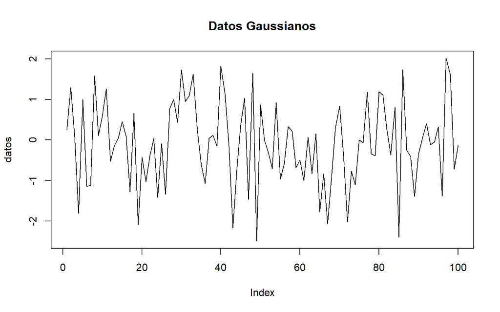

```r
datos <- rnorm(100,mean=0, sd=1)
plot(datos, type="l", main="Datos Gaussianos")
```

Existen muchas otras distribuciones continuas y el objetivo de ellas es adecuar nuestros datos a una de ellas con el objetivo de simular situaciones con valores tomados de ellas.

### Tarea

Investigar las siguientes distribuciones continuas de probabilidad (pueden incorporar el código en `R` que las genera aunque es opcional).

- Distribución uniforme continua.
- Distribución exponencial.
- Distribución Rayleigh
- Distribución Gamma.

La tarea se debe entregar el día Miércoles 18 de octubre de 2023. Atte. Dr. Julio César Ramírez Pacheco.